# Constructing a Multi-popopulation Mortality Model

Jens Robben

22-12-2020

## Setup

We illustrate the use of the `MultiMoMo` package.

Load the required packages

```r
require(MultiMoMo)
```

## Downloading the mortality data

Int this section, we download annual data on the observed number of deaths, $d_{x,t}$, and the corresponding exposures to risk, $E_{x,t}$, for a set of countries over a specified calibration period and over a specified age range. We collect this data from two data sources: the Human Mortality Database (HMD) and Eurostat. Further we use a collection of 14 European countries.

First, the available countries, their country labels and the available years can be retrieved as follows:

```r
df <- get_country_codes()
head(df[,c(1,8,6,7,2,3)])
```

```
##      Country User_code   FY   EY in_HMD in_Eurostat
## 1    Albania        AL 2013 2018  FALSE        TRUE
## 2    Andorra        AD 2006 2012  FALSE        TRUE
## 3    Armenia        AM 2018 2018  FALSE        TRUE
## 4  Australia        AU 1921 2018   TRUE       FALSE
## 5    Austria        AT 1947 2018   TRUE        TRUE
## 6 Azerbaijan        AZ 2018 2018  FALSE        TRUE
```

Make sure that your selected calibration period falls within the available year range $[FY,EY]$ for each country in your multi-population model. The column `User_code` in this data frame refers to the user codes of the different countries. Those user codes are used to refer to the countries of interest.

Next, we download the mortality data from the Human Mortality Database (HMD) and Eurostat. We collect the data for age range $\{0,1,2,...,90\}$ and calibration period $\{1988, 1989, ..., 2018\}$. We are interested in retrieving mortality statistics from Belgium (country of interest). From the HMD database we use the tables `Deaths` and `Exposure to risk` in $1\times1$ format. These files contain the number of deaths and exposures for the selected country per year, per sex and per age in period format. Eurostat only lists the period number of deaths. However, we obtain the exposures in period format using databases on the population size at $1$ January of each year $t$, say $P_{x,t}$, and the cohort number of deaths, say $C_{x,t}$, as defined according to the protocol of HMD. The cohort number of deaths $C_{x,t}$ refers to the number of people who were born in year $t-x-1$ and died in year $t$. Adjusting to the HMD protocol requires the following transformations:
$$\begin{eqnarray*}
E_{x,t} &=& \frac{1}{2} \left( P_{x,t} + P_{x,t+1} \right) + \frac{1}{6} \left(\frac{1}{2}C_{x,t} - \frac{1}{2}C_{x+1,t} \right) \ \ \text{if}\ x>0 \\
E_{0,t} &=& \frac{1}{2} \left( P_{0,t} + P_{0,t+1} \right) + \frac{1}{6} \left(C_{0,t} - \frac12 C_{1,t}\right).\\
\end{eqnarray*}$$
We perform this automatic downloading and adjusting process using the following code chunk:

```r
xv <- 0:90
yv <- 1988:2018
yv_spec <- 1988:2018
countries <- c("AT", "BE", "DK", "FI", "FR", "DE", "IS", "IE", "LU", "NL", "NO", "SE", "CH", "UK")
country_spec <- "BE"
username <- ""
password <- ""
data <- get_mortality_data(xv, yv, yv_spec, countries, country_spec, username, password)
```

In order to be able to run the above code chunk, you first need to create an account on the [Human Mortality Database](https://www.mortality.org) and provide your username and password at the correct place within the code. Running this code can take a few minutes, depending on the number of countries you use in the multi-population model. We selected the countries as the ones with a gross-domestic-product above the European average in 2018. Our country of interest is Belgium.

The package `MultiMoMo` provides such an example dataset (using the same set of countries as above). We adjust the year range to the one above using the function `get_data_specific_range`.

```r
xv <- 0:90
yv <- 1988:2018
yv_spec <- 1988:2018
countries <- c("AT", "BE", "DK", "FI", "FR", "DE", "IS", "IE", "LU", "NL", "NO", "SE", "CH", "UK")
country_spec <- "BE"
data <- MultiMoMo::european_mortality_data
data <- get_data_specific_range(xv, yv, yv_spec, data, countries, country_spec)
dimnames(data$M$UNI$BE$dtx)
```

```
## [[1]]
##  [1] "1988" "1989" "1990" "1991" "1992" "1993" "1994" "1995" "1996" "1997"
## [11] "1998" "1999" "2000" "2001" "2002" "2003" "2004" "2005" "2006" "2007"
## [21] "2008" "2009" "2010" "2011" "2012" "2013" "2014" "2015" "2016" "2017"
## [31] "2018"
##
## [[2]]
##  [1] "0"  "1"  "2"  "3"  "4"  "5"  "6"  "7"  "8"  "9"  "10" "11" "12" "13" "14"
## [16] "15" "16" "17" "18" "19" "20" "21" "22" "23" "24" "25" "26" "27" "28" "29"
## [31] "30" "31" "32" "33" "34" "35" "36" "37" "38" "39" "40" "41" "42" "43" "44"
## [46] "45" "46" "47" "48" "49" "50" "51" "52" "53" "54" "55" "56" "57" "58" "59"
## [61] "60" "61" "62" "63" "64" "65" "66" "67" "68" "69" "70" "71" "72" "73" "74"
## [76] "75" "76" "77" "78" "79" "80" "81" "82" "83" "84" "85" "86" "87" "88" "89"
## [91] "90"
```

## Model specification

The mortality model structures the logarithm of the force of mortality for Belgium, $\mu_{x,t}^{\text{BE}}$, as follows
$$\begin{eqnarray}
\ln \mu_{x,t}^{\text{BE}} &=& \ln \mu_{x,t}^{\text{EU}}+\ln \tilde{\mu}_{x,t}^{\text{BE}} \label{eq:fullmu}\\
\ln \mu_{x,t}^{\text{EU}} &=& A_x + B_xK_t \label{eq:Europe} \\
\ln \tilde{\mu}_{x,t}^{\text{BE}} &=& \alpha_x + \beta_x \kappa_t. \label{eq:Belgium},
\end{eqnarray}$$
We recognize two times a Lee & Carter specification; is a LC model for the European evolution of mortality (driven by $\mu_{x,t}^{\text{EU}}$) and is a LC model for the Belgian deviation from this common trend (specified by $\tilde{\mu}_{x,t}^{\text{BE}}$). We calibrate this model on data with ages ranging from 0 up to 90, thus $\mathcal{X}=\{0,\ldots,90\}$, and a calibration period from $t_{\text{start}}$ up to 2018 for the European mortality trend. The same calibration period is used for the Belgian deviation from this common European mortality trend.

For the time dependent parameters, $K_t$ and $\kappa_t$, the following time series models are used
$$\begin{eqnarray}
K_{t+1} &=& K_t+\theta + \epsilon_{t+1} \label{RWD} \\
\kappa_{t+1} &=& c + \phi\kappa_{t}+\delta_{t+1}, \label{AR1}
\end{eqnarray}$$
for males and females. This leads to four stochastic processes ($K_t^{M}, \kappa_t^M, K_t^F, \kappa_t^F$). The dynamics of the common period effect (see $\eqref{RWD}$), $K_t$, are modeled with a Random Walk with Drift ([RWD]), where $\theta$ is the drift and $\epsilon_{t+1}$ is white noise. The Belgian period effect (see $\eqref{AR1}$) $\kappa_t$ follows, in contrast with the model, an AR(1) process with intercept $c$.

Further, we will jointly model the time series dynamics for men and women by assuming a multivariate Gaussian distribution with mean $(0,0,0,0)$ and covariance matrix $\boldsymbol{C}$ for the error terms $\left(\epsilon_t^{M},\delta_t^{M},\epsilon_t^{F},\delta_t^{F}\right)$. We calibrate the parameters in these time series specifications on the estimated $K_t$ and $\kappa_t$ parameters, for $t\in \mathcal{T}$, and use these dynamics to forecast $\mu_{x,t}^{\text{BEL}}$ for $t \in \{2019, 2020,\ldots,t_{\max}\}$.

## Model calibration

We calibrate the parameters ($A_x$, $B_x$, $K_t$, $\alpha_x$, $\beta_x$ and $\kappa_t$) in the LL specification using Maximum Likelihood Estimation. We assume a Poisson distribution for the number of deaths random variable $D_{x,t}$, with mean $E_{x,t} \cdot \mu_{x,t}$ and $E_{x,t}$ the observed exposure to risk. To avoid identification problems in the LL model we use a conditional maximum likelihood approach. We calibrate the common parameters (i.e.~$A_x$, $B_x$ and $K_t$) in a first step, followed by the calibration of the Belgian parameters (i.e.~$\alpha_x$, $\beta_x$ and $\kappa_t$) in a second step. We apply this calibration strategy separately for males and females. This is done using the following bunch of code

```r
fit_M <- fit_li_lee(xv, yv, yv_spec, country_spec, data = data$M, method = "NR", Ax = TRUE, exclude_coh = FALSE)
fit_F <- fit_li_lee(xv, yv, yv_spec, country_spec, data = data$F, method = "NR", Ax = TRUE, exclude_coh = FALSE)
```

The calibrated parameters for males can be visualized as follows:

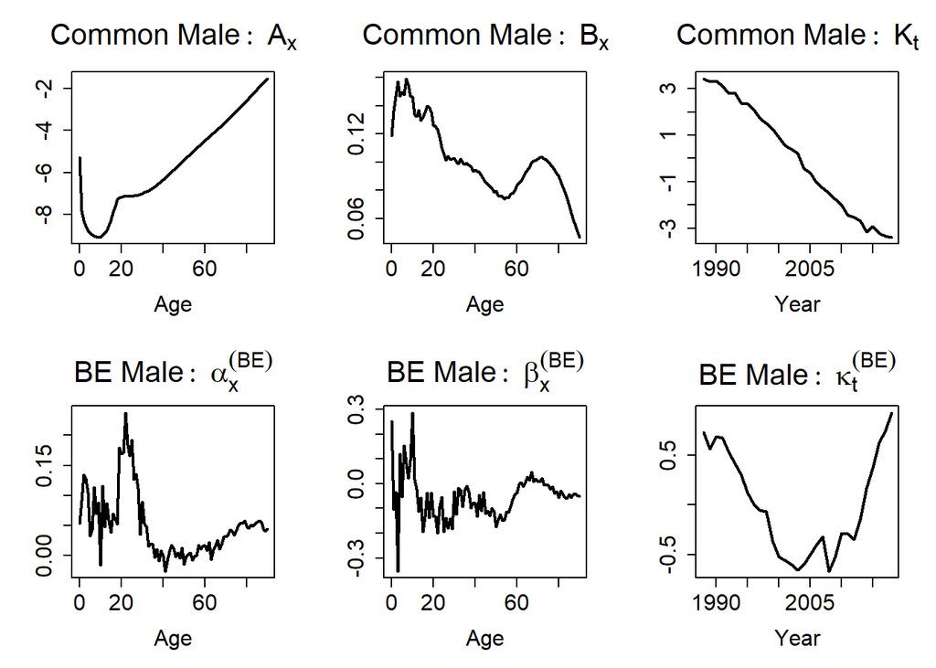

```r
plot_parameters_li_lee(xv, yv_spec, fit_M, sex = "Male", country_spec, method = "NR", type = "ALL")
```

[figure not shown]

```r
plot_parameters_li_lee(xv, yv_spec, fit_M, sex = "Female", country_spec, method = "NR", type = "k.t")
```

## Projection

The start year of the calibration period, namely the year 1988, is chosen in such a way, that the fitted AR(1) time series processes are stable for both males and females (see Antonio et. al (2020)).

Within this package, this translates into the following code. We project the time dependent parameters until the year 2070 plus an additional 120 years, such that we will be able to make projections for the life expectancy until the year 2070 (we will close the mortality tables at the age of 120). This will be covered later on. We do 10 000 simulations.

```r
arima_spec <- list(K.t_M = "RWD", k.t_M = "AR1.1", K.t_F = "RWD", k.t_F = "AR1.1")
n_ahead    <- length(2019:2070) + 120
n_sim      <- 10000
est_method <- "PORT"
proj_par   <- project_parameters(fit_M, fit_F, n_ahead, n_sim, arima_spec, est_method)
```

To show that the estimated time series processes for the Belgian deviation model are stable, we need to verity that the AR(1) parameter estimates are smaller than 1.

```r
proj_par$coef_ktM
```

```
## [1] 0.002662477 0.869899400
```

```r
proj_par$coef_ktF
```

```
## [1] -0.02090481  0.94579768
```

The estimated covariance matrix $\boldsymbol{C}$ of the error terms $\left(\epsilon_t^{M},\delta_t^{M},\epsilon_t^{F},\delta_t^{F}\right)$ equals:

```r
proj_par$cov_mat
```

```
##             K.t_M        k.t_M        K.t_F       k.t_F
## K.t_M 0.030047523 0.0046776969 0.0362155040 0.006288700
## k.t_M 0.004677697 0.0279541523 0.0009645256 0.001573022
## K.t_F 0.036215504 0.0009645256 0.0469075668 0.007381617
## k.t_F 0.006288700 0.0015730217 0.0073816165 0.032007244
```

The corresponding correlation matrix of the error terms $\left(\epsilon_t^{M},\delta_t^{M},\epsilon_t^{F},\delta_t^{F}\right)$ can then be calculated as

```r
S <- proj_par$cov_mat
D <- diag(sqrt(diag(S)))
Dinv <- solve(D)
R <- Dinv %*% S %*% Dinv
dimnames(R) <- dimnames(S)
R
```

```
##           K.t_M      k.t_M      K.t_F      k.t_F
## K.t_M 1.0000000 0.16140039 0.96464771 0.20278338
## k.t_M 0.1614004 1.00000000 0.02663601 0.05258809
## K.t_F 0.9646477 0.02663601 1.00000000 0.19050478
## k.t_F 0.2027834 0.05258809 0.19050478 1.00000000
```

Using the simulations/projections of the time dependent parameters $\{(K_t,\kappa_t)\ |\ t\in \mathcal{T}\}$, we can construct projections for the Belgian mortality rates.

```r
proj_rates <- project_mortality_rates(fit_M, fit_F, proj_par)
```

## Closing mortality rates

The Belgian mortality rates $q_{x,t}^{\text{BE}}$ for males and females need to be closed in order to make reliable projections for the life expectancy.

We use the method of Kannistö to close each mortality scenario for old ages, say $x\in \{91,92,\ldots,120\}$. This parametric mortality law specifies the force of mortality in each scenario $i$, for ages $x>90$ and a specific year $t$, as follows:
$$\begin{eqnarray}\label{eq:KanADSEIto}
\mu_{x,t}^{i} &=& \frac{\phi_1^{i,t} \exp{(\phi_2^{i,t} x)}}{1+\phi_1^{i,t}\exp{(\phi_2^{i,t} x)}}.
\end{eqnarray}$$
We estimate $(\phi_1^i,\phi_2^i)$ for each scenario $i$ and year $t$ using the relation (see )
$$\begin{eqnarray}\label{eq:KanADSEItoLogit}
\text{logit}\ \mu_{x,t}^{i} &=& \log{(\phi_1^{i,t})}+\phi_2^{i,t} x,
\end{eqnarray}$$
which we estimate with ordinary least squares estimation on the ages $x\in \{80,81,\ldots,90\}$. The estimates for $(\phi_1^{i,t},\phi_2^{i,t})$ are then used to close the generated mortality scenario for ages $x>90$.

Finally, we can switch to scenarios for future mortality rates using the transformation:
$$\begin{eqnarray}
q_{x,t}^{i} &=& 1-\exp{(-\mu_{x,t}^i)},
\end{eqnarray}$$
for $t=2019,2020,\ldots,t_{\max}$ and $x\in 0,1,\ldots, 120$.

The closing procedure can be executed with the following bunch of code:

```r
kannisto_nages <- 30
kannisto_nobs  <- 11
close_rates_M  <- close_mortality_rates(yv_spec, proj_rates$Male, kannisto_nages, kannisto_nobs)
close_rates_F  <- close_mortality_rates(yv_spec, proj_rates$Female, kannisto_nages, kannisto_nobs)
dim(close_rates_M)
```

```
## [1]   121   203 10000
```

## Period and cohort life expectancy

From the simulated scenarios for future mortality rates we obtain simulations for the period as well as cohort life expectancy. Using the assumption of piecewise constant force of mortality, the period life expectancy for an $x$ year old in year $t$ equals
$$\begin{eqnarray}
e_x^{\text{per}}(t) &=& \frac{1-\exp{(-\mu_{x,t})}}{\mu_{x,t}}+\sum_{k\geq 1} \left(\prod_{j=0}^{k-1} \exp{(-\mu_{x+j,t})}\right)\frac{1-\exp{(-\mu_{x+k,t})}}{\mu_{x+k,t}},
\end{eqnarray}$$
and the cohort life expectancy for an $x$ year old in year $t$ is
$$\begin{eqnarray}
e_x^{\text{coh}}(t) &=& \frac{1-\exp{(-\mu_{x,t})}}{\mu_{x,t}}+\sum_{k\geq 1} \left(\prod_{j=0}^{k-1} \exp{(-\mu_{x+j,t+j})}\right)\frac{1-\exp{(-\mu_{x+k,t+k})}}{\mu_{x+k,t+k}},
\end{eqnarray}$$
Using the generated mortality scenarios we obtain simulations of the period and cohort life expectancy, say $e_x^{\text{per},i}(t)$ and $e_x^{\text{coh},i}(t)$.

This results in the R-code:

```r
le_yv   <- 1988:2070
le_ages <- c(0,65)
le_type <- c("per", "coh")
le_M    <- life_exp(le_yv, le_type, le_ages, close_rates_M)
le_F    <- life_exp(le_yv, le_type, le_ages, close_rates_F)
```

Next, we can visualize the simulated period and cohort life expectancies. But, first, we will calculate the observed death rates during the years 1988-2018. This will give us later on a visual idea how well our fitted period life expectancies correspond to the observed ones. We focus on the males.

```r
deaths_obs <- data$M$UNI$BE$dtx
exp_obs    <- data$M$UNI$BE$etx
kannisto_nages <- 30
kannisto_nobs  <- 11
close_obs_m    <- close_obs_death_rates(deaths_obs, exp_obs, kannisto_nages, kannisto_nobs)
```

Lastly, we perform the visualization of the simulated period and cohort life expectancies for males and for the ages 0 and 65. We visualize a 99% confidence bound.

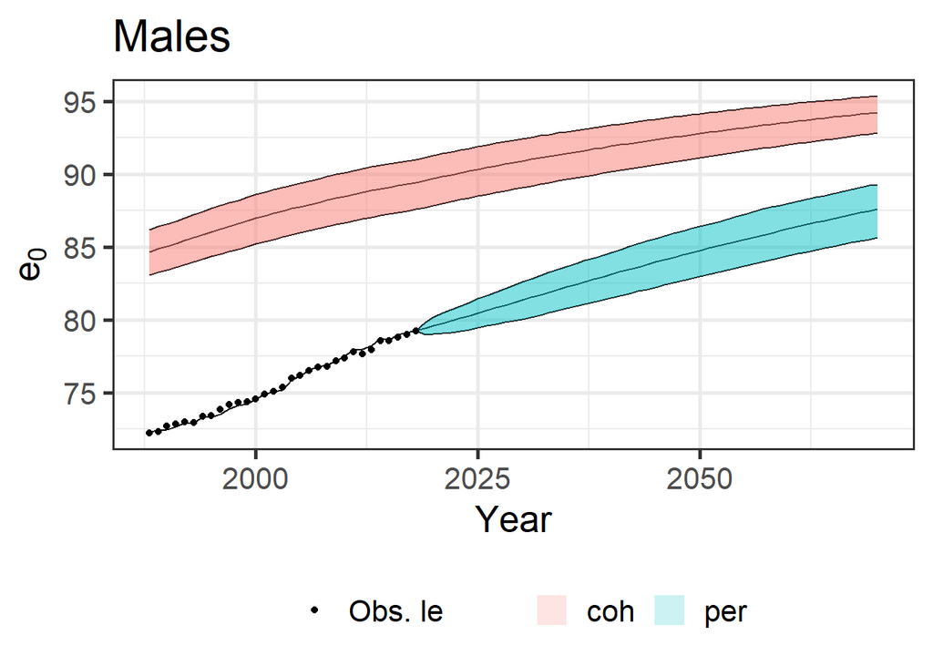

```r
plot_life_exp(le_yv, age = 0, le_sim = le_M, sex = "Male", type = le_type, quantile = "99%", m_obs = close_obs_m)
```

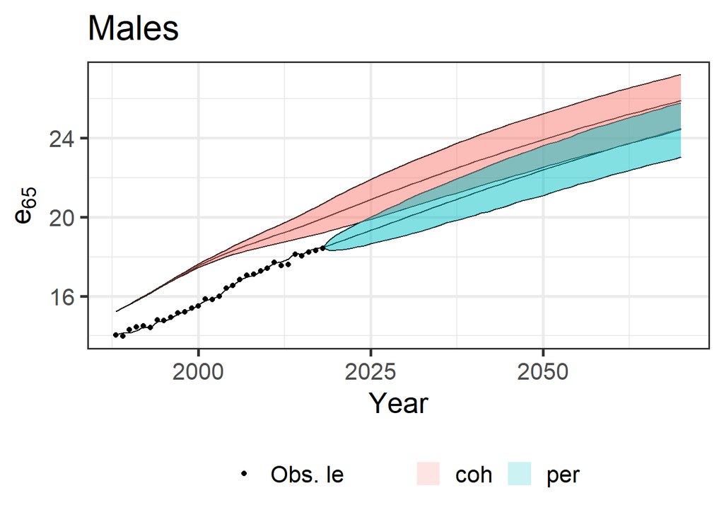

```r
plot_life_exp(le_yv, age = 65, le_sim = le_M, sex = "Male", type = le_type, quantile = "99%", m_obs = close_obs_m)
```